# Advanced Statistics for Physics Analysis

## R Lab 01

### Student: Toso Simone (2095484)

## Ex.1 - American Airlines Employees

#### 1) Read data and import them into a data.frame or tibble structure

```r
#Import tidyverse packages
library(tidyverse)
library(patchwork)
```

```r
#Filenames and company names
filenames <- c("american_airline_empl.txt","delta_airline_empl.txt","federal_express_empl.txt","united_airline_empl.txt")
companies <- c("AmericanAirline", "DeltaAirline", "FedEx", "UnitedAirline")
```

```r
#Read files
am_air <- as_tibble(read_delim(filenames[1],show_col_types = FALSE))
del_air <- as_tibble(read_delim(filenames[2],show_col_types = FALSE))
fed_ex <- as_tibble(read_delim(filenames[3],show_col_types = FALSE))
un_air <- as_tibble(read_delim(filenames[4],show_col_types = FALSE))
```

#### 2) Merge the four data tibble in a common tibble

```r
# Add to each tibble a column with the company's name, then perform inner-join
am_air<- am_air %>% add_column(CompanyName = rep(companies[[1]], nrow(am_air)))
del_air <- del_air %>% add_column(CompanyName = rep(companies[[2]], nrow(am_air)))
fed_ex <- fed_ex %>% add_column(CompanyName = rep(companies[[3]], nrow(am_air)))
un_air <- un_air %>% add_column(CompanyName = rep(companies[[4]], nrow(am_air)))

#Merge using innerjoin. Now total contains the complete tibble
total <- rbind(am_air,del_air,fed_ex,un_air)

#Show the head of the total tibble as an example
head(total)
```

A tibble: 6 × 6

| Month <dbl> | Year <dbl> | Full-time <dbl> | Part-time <dbl> | Grand Total <dbl> | CompanyName <chr> |
| --- | --- | --- | --- | --- | --- |
| 1 | 1990 | 68137 | 9039 | 77176 | AmericanAirline |
| 2 | 1990 | 68725 | 9273 | 77998 | AmericanAirline |
| 3 | 1990 | 69509 | 9376 | 78885 | AmericanAirline |
| 4 | 1990 | 69713 | 9326 | 79039 | AmericanAirline |
| 5 | 1990 | 70376 | 9309 | 79685 | AmericanAirline |
| 6 | 1990 | 71258 | 9369 | 80627 | AmericanAirline |

#### 3) Produce a plot of the behaviour of the employees as a function of time for all four companies, separately for full-time and part-time employees

```r
#Add a "Time" column, with form year-month-day
total <- total %>% add_column(Time = ymd(sprintf("%02d/%02d/%02d", total$Year, total$Month,01)))
head(total)
```

A tibble: 6 × 7

| Month <dbl> | Year <dbl> | Full-time <dbl> | Part-time <dbl> | Grand Total <dbl> | CompanyName <chr> | Time <date> |
| --- | --- | --- | --- | --- | --- | --- |
| 1 | 1990 | 68137 | 9039 | 77176 | AmericanAirline | 1990-01-01 |
| 2 | 1990 | 68725 | 9273 | 77998 | AmericanAirline | 1990-02-01 |
| 3 | 1990 | 69509 | 9376 | 78885 | AmericanAirline | 1990-03-01 |
| 4 | 1990 | 69713 | 9326 | 79039 | AmericanAirline | 1990-04-01 |
| 5 | 1990 | 70376 | 9309 | 79685 | AmericanAirline | 1990-05-01 |
| 6 | 1990 | 71258 | 9369 | 80627 | AmericanAirline | 1990-06-01 |

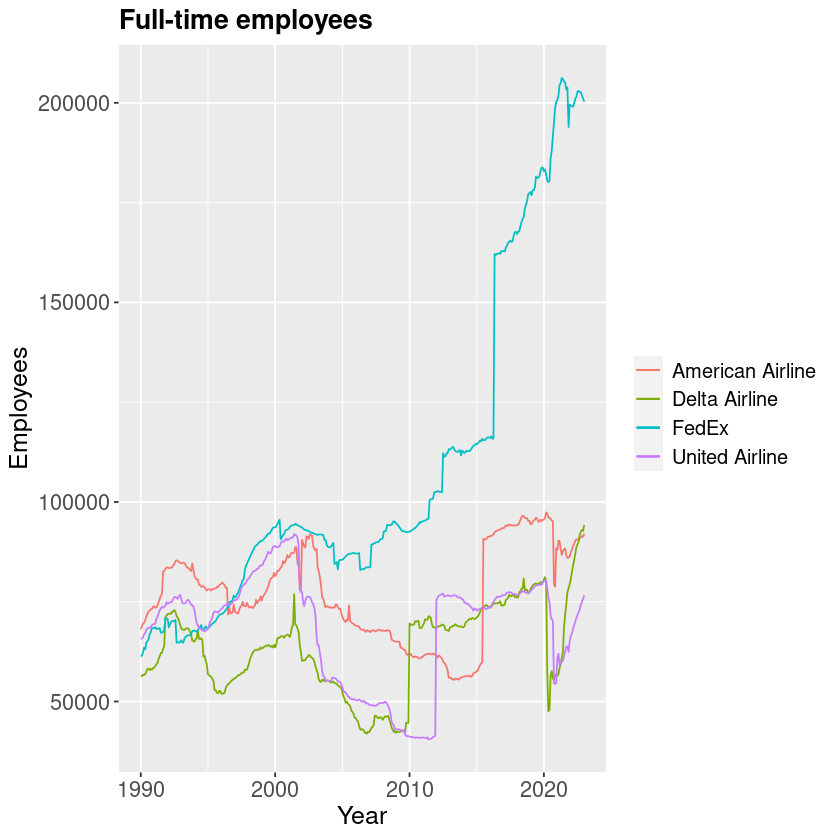

```r
#Full-time
line_am <- geom_line(total[total$CompanyName == "AmericanAirline", ], mapping = aes(x = total[total$CompanyName == "AmericanAirline", ]$Time, y = total[total$CompanyName == "AmericanAirline", ]$"Full-time", color = "American Airline"))
line_del <- geom_line(total[total$CompanyName == "DeltaAirline", ], mapping = aes(x = total[total$CompanyName == "DeltaAirline", ]$Time, y = total[total$CompanyName == "DeltaAirline", ]$"Full-time", color = "Delta Airline"))
line_fed <- geom_line(total[total$CompanyName == "FedEx", ], mapping = aes(x = total[total$CompanyName == "FedEx", ]$Time, y = total[total$CompanyName == "FedEx", ]$"Full-time", color  ="FedEx"))
line_un <- geom_line(total[total$CompanyName == "UnitedAirline", ], mapping = aes(x = total[total$CompanyName == "UnitedAirline", ]$Time, y = total[total$CompanyName == "UnitedAirline", ]$"Full-time", color = "United Airline"))

p <- ggplot() + line_am + line_del + line_fed + line_un + labs(x = "Year", y = "Employees") + ggtitle("Full-time employees") + theme(legend.text = element_text(size = 12), axis.title = element_text(size = 15), axis.text = element_text(size = 13), plot.title = element_text(face = "bold", size = 16)) + labs(color = NULL)
p
```

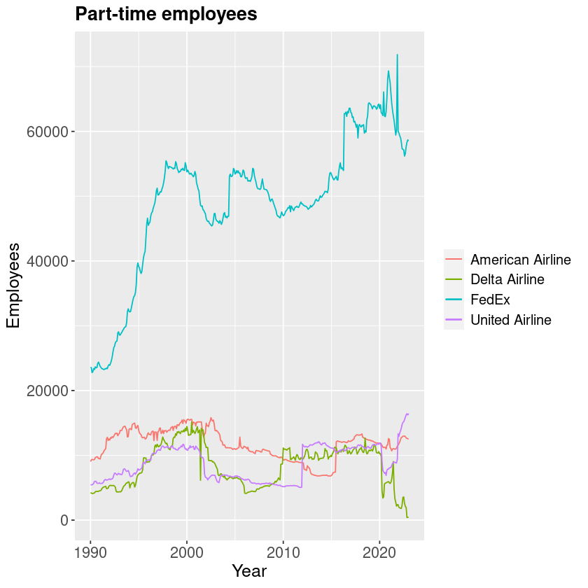

```r
#Part-time
line_am_part <- geom_line(total[total$CompanyName == "AmericanAirline", ], mapping = aes(x = total[total$CompanyName == "AmericanAirline", ]$Time, y = total[total$CompanyName == "AmericanAirline", ]$"Part-time", color = "American Airline"))
line_del_part <- geom_line(total[total$CompanyName == "DeltaAirline", ], mapping = aes(x = total[total$CompanyName == "DeltaAirline", ]$Time, y = total[total$CompanyName == "DeltaAirline", ]$"Part-time", color = "Delta Airline"))
line_fed_part <- geom_line(total[total$CompanyName == "FedEx", ], mapping = aes(x = total[total$CompanyName == "FedEx", ]$Time, y = total[total$CompanyName == "FedEx", ]$"Part-time", color  ="FedEx"))
line_un_part <- geom_line(total[total$CompanyName == "UnitedAirline", ], mapping = aes(x = total[total$CompanyName == "UnitedAirline", ]$Time, y = total[total$CompanyName == "UnitedAirline", ]$"Part-time", color = "United Airline"))

q <- ggplot() + line_am_part + line_del_part + line_fed_part + line_un_part + labs(x = "Year", y = "Employees") + ggtitle("Part-time employees") + theme(legend.text = element_text(size = 12), axis.title = element_text(size = 15), axis.text = element_text(size = 13), plot.title = element_text(face = "bold", size = 16)) + labs(color = NULL)
q
```

#### 4) When did each company reach the minimum and maximum number of employees?

```r
#Add a column with total number of employees
total <- total %>% add_column(Total = total$"Full-time" + total$"Part-time")
```

```r
#Store times of minima and maxima
minimaTimes <- c()
maximaTimes <- c()

#Check for each company
for(company in companies){
    minimaTimes <- c(minimaTimes, toString(total[total$CompanyName == company, ]$"Time"[which.min(total[total$CompanyName == company, ]$"Total")]))
    maximaTimes <- c(maximaTimes, toString(total[total$CompanyName == company, ]$"Time"[which.max(total[total$CompanyName == company, ]$"Total")]))
}
```

```r
#Show data in dataframe
(data.frame(Company = companies, timeMin=minimaTimes, timeMax = maximaTimes))
```

A data.frame: 4 × 3

| Company <chr> | timeMin <chr> | timeMax <chr> |
| --- | --- | --- |
| AmericanAirline | 2013-09-01 | 2018-06-01 |
| DeltaAirline | 2006-11-01 | 2023-01-01 |
| FedEx | 1990-01-01 | 2021-03-01 |
| UnitedAirline | 2011-06-01 | 2001-03-01 |

#### 5) Plot the fraction of part-time worker over the total employees as a function of time

```r
# We add a column to the tibble
total <- total %>% add_column("Part-time/Total" = total$"Part-time"/total$"Total")
```

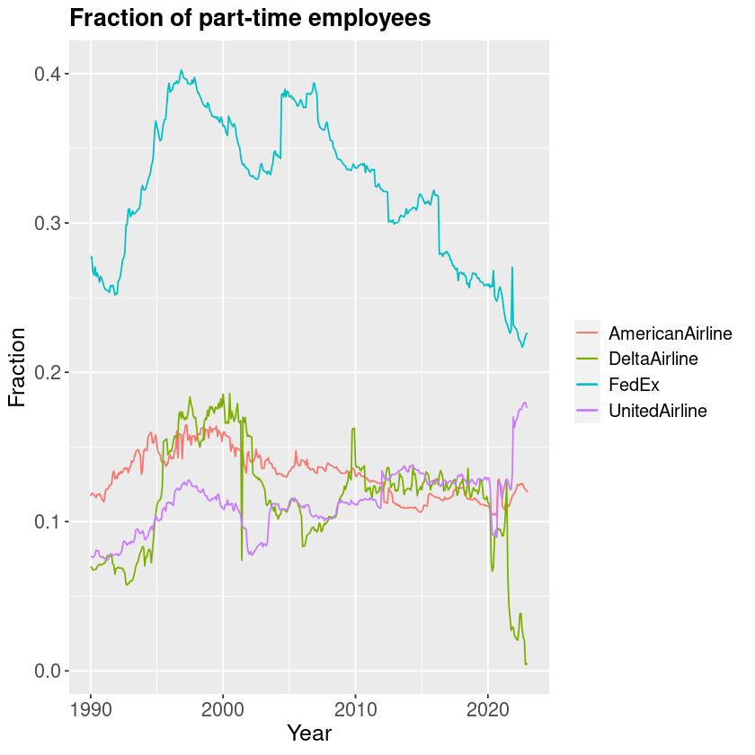

```r
# We plot the fraction as a function of time for each company
plot <- ggplot()

line_am <- geom_line(aes(x = total[total$CompanyName == companies[1], ]$Time, y = total[total$CompanyName == companies[1], ]$"Part-time/Total", color = companies[1]))
line_del <- geom_line(aes(x = total[total$CompanyName == companies[2], ]$Time, y = total[total$CompanyName == companies[2], ]$"Part-time/Total", color = companies[2]))
line_fed <- geom_line(aes(x = total[total$CompanyName == companies[3], ]$Time, y = total[total$CompanyName == companies[3], ]$"Part-time/Total", color = companies[3]))
line_un <- geom_line(aes(x = total[total$CompanyName == companies[4], ]$Time, y = total[total$CompanyName == companies[4], ]$"Part-time/Total", color = companies[4]))

labels <- labs(x = "Year", y = "Fraction", color = NULL)
themes <- theme(legend.text = element_text(size = 12), axis.title = element_text(size = 15), axis.text = element_text(size = 13), plot.title = element_text(face = "bold", size = 16))

plot <- plot + line_am + line_del + line_fed + line_un + themes + labels + ggtitle("Fraction of part-time employees")
print(plot)
```

#### 6) Did the COVID-19 pandemic have any influence in the employed workers of the airline companies? Can you see a trend in the years 2019-2023?

The number of full-time employees of American Airline, Delta Airline and United Airline experienced a sharp drop at the beginning of 2020. FedEx was an exception, perhaps because it is a cargo airline, whereas the other companies specialize in passenger flights. The companies which lost full-time employees in 2020 started regaining employees in the following years.

## Ex. 2 - Data Frames and Tibble

```r
library(nycflights13) #Import dataset
```

#### 1.1) Plot the total number of flights departed from each of the three NYC airports as a function of time (one entry for each of the 365 days of the year)

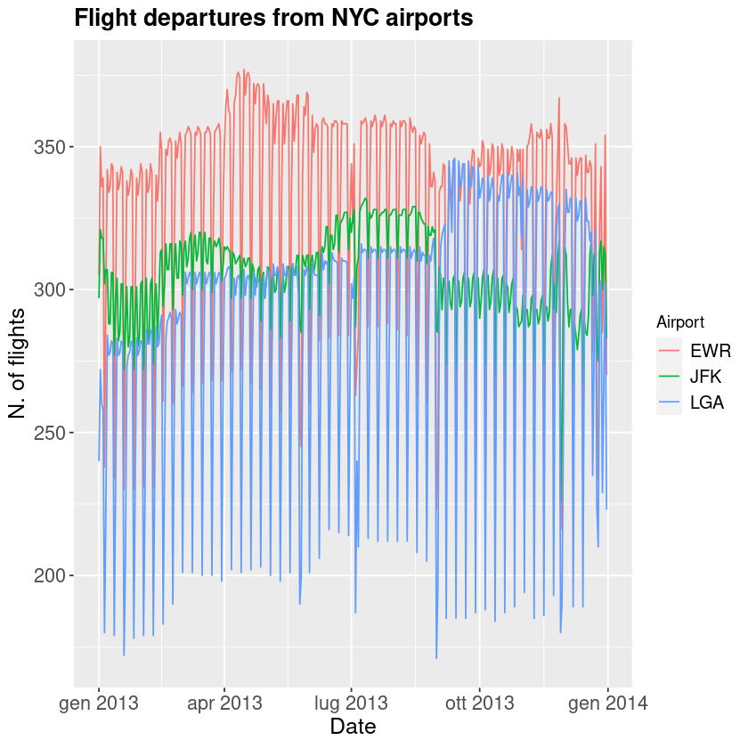

```r
#Count for each day the number of rows
nyc_airports <- c("EWR", "LGA", "JFK")

flightCount <- count(flights, year, month, day, origin)
flightCount <- flightCount %>% add_column(date = ymd(sprintf("%d/%02d/%02d", flightCount$year, flightCount$month, flightCount$day)))

#Plot a line for each airport
plot <- ggplot(data = flightCount, aes(x = date, y = n, group=origin)) + geom_line(aes(color = origin))

labels <- labs(x = "Date", y = "N. of flights", colour = "Airport")
themes <- theme(legend.text = element_text(size = 12), axis.title = element_text(size = 15), axis.text = element_text(size = 13), plot.title = element_text(face = "bold", size = 16))

plot <- plot + labels + themes + ggtitle("Flight departures from NYC airports")
print(plot)
```

#### 1.2) Plot the average number of flights computed over the first five working days of each week as a function of the week number of the year. Produce the same plot for the flights departing over the weekend (Saturdays and Sundays)

```r
#Find week number
flightCount <- flightCount %>% add_column(week = week(flightCount$date))

#Find day of week (0 = Sunday, 1 = Monday, ... , 6 = Saturday)
flightCount <- flightCount %>% add_column(weekDay = as.POSIXlt(flightCount$date)$wday)
```

```r
#Visualize tibble
head(flightCount)
```

A tibble: 6 × 8

| year <int> | month <int> | day <int> | origin <chr> | n <int> | date <date> | week <dbl> | weekDay <int> |
| --- | --- | --- | --- | --- | --- | --- | --- |
| 2013 | 1 | 1 | EWR | 305 | 2013-01-01 | 1 | 2 |
| 2013 | 1 | 1 | JFK | 297 | 2013-01-01 | 1 | 2 |
| 2013 | 1 | 1 | LGA | 240 | 2013-01-01 | 1 | 2 |
| 2013 | 1 | 2 | EWR | 350 | 2013-01-02 | 1 | 3 |
| 2013 | 1 | 2 | JFK | 321 | 2013-01-02 | 1 | 3 |
| 2013 | 1 | 2 | LGA | 272 | 2013-01-02 | 1 | 3 |

```r
#Increase the weekcount of each Monday by one, so that they are alligned (Monday is the first workday of each week)
flightCount[flightCount$weekDay == 1, ]$week <- flightCount[flightCount$weekDay == 1, ]$week +1
```

```r
#Show tail of tibble as an example. 2013-12-30 is a Monday and correctly falls on week 53.
tail(flightCount,10)
```

A tibble: 10 × 8

| year <int> | month <int> | day <int> | origin <chr> | n <int> | date <date> | week <dbl> | weekDay <int> |
| --- | --- | --- | --- | --- | --- | --- | --- |
| 2013 | 12 | 28 | LGA | 229 | 2013-12-28 | 52 | 6 |
| 2013 | 12 | 29 | EWR | 304 | 2013-12-29 | 52 | 0 |
| 2013 | 12 | 29 | JFK | 315 | 2013-12-29 | 52 | 0 |
| 2013 | 12 | 29 | LGA | 269 | 2013-12-29 | 52 | 0 |
| 2013 | 12 | 30 | EWR | 354 | 2013-12-30 | 53 | 1 |
| 2013 | 12 | 30 | JFK | 312 | 2013-12-30 | 53 | 1 |
| 2013 | 12 | 30 | LGA | 302 | 2013-12-30 | 53 | 1 |
| 2013 | 12 | 31 | EWR | 270 | 2013-12-31 | 53 | 2 |
| 2013 | 12 | 31 | JFK | 283 | 2013-12-31 | 53 | 2 |
| 2013 | 12 | 31 | LGA | 223 | 2013-12-31 | 53 | 2 |

The column `flightCount$week` contains the week number, with each week going from Monday to Sunday. The first week starts on a Tuesday and therefore has only six days.

```r
#For each week number and airport, compute average over days 1:5 (work days) and {0,6} (weekend)
weeklyMeans <- aggregate(flightCount$n, list(week = flightCount$week, workday = flightCount$weekDay >= 1 & flightCount$weekDay <=5, origin = flightCount$origin), mean)

#To have the average number of flights, regardless of the airport, we sum across the origin
weeklyMeans <- aggregate(weeklyMeans$x, list(week = weeklyMeans$week, workday = weeklyMeans$workday), sum)
```

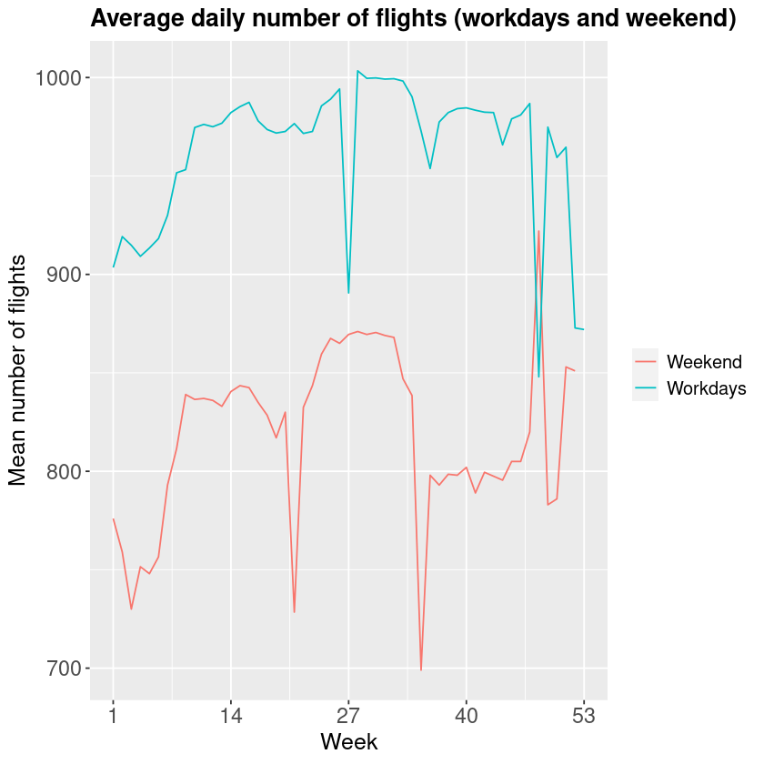

```r
plot <- ggplot(data = weeklyMeans, aes(x = week, y = x, group = workday)) + geom_line(aes(color = workday))
labels <- labs(x = "Week", y = "Mean number of flights", colour = "Workday")
themes <- theme(legend.text = element_text(size = 12), axis.title = element_text(size = 15), axis.text = element_text(size = 14), plot.title = element_text(face = "bold", size = 16))
x_ticks <- seq(1,53,by = 13)

plot <- plot + labels + themes + ggtitle("Average daily number of flights (workdays and weekend)") + scale_color_discrete(name = NULL, labels = c("Weekend", "Workdays"))+ scale_x_continuous(breaks= x_ticks)


print(plot)
```

#### 2) For each flight in the data frame, compute the departure delay and extract the following pieces of information (separately for each NYC airport):

```
- min, max and average delay for each day of the year (show the data in corresponding plots)
```

```r
flights <- flights %>% add_column(date = ymd(sprintf("%02d/%02d/%02d", flights$year, flights$month, flights$day)))
```

```r
#Check if NA values
head(flights[(is.na(flights$dep_delay)),]) #There are 8255 entries with dep_delay = NA
```

A tibble: 6 × 20

| year <int> | month <int> | day <int> | dep_time <int> | sched_dep_time <int> | dep_delay <dbl> | arr_time <int> | sched_arr_time <int> | arr_delay <dbl> | carrier <chr> | flight <int> | tailnum <chr> | origin <chr> | dest <chr> | air_time <dbl> | distance <dbl> | hour <dbl> | minute <dbl> | time_hour <dttm> | date <date> |
| --- | --- | --- | --- | --- | --- | --- | --- | --- | --- | --- | --- | --- | --- | --- | --- | --- | --- | --- | --- |
| 2013 | 1 | 1 | NA | 1630 | NA | NA | 1815 | NA | EV | 4308 | N18120 | EWR | RDU | NA | 416 | 16 | 30 | 2013-01-01 16:00:00 | 2013-01-01 |
| 2013 | 1 | 1 | NA | 1935 | NA | NA | 2240 | NA | AA | 791 | N3EHAA | LGA | DFW | NA | 1389 | 19 | 35 | 2013-01-01 19:00:00 | 2013-01-01 |
| 2013 | 1 | 1 | NA | 1500 | NA | NA | 1825 | NA | AA | 1925 | N3EVAA | LGA | MIA | NA | 1096 | 15 | 0 | 2013-01-01 15:00:00 | 2013-01-01 |
| 2013 | 1 | 1 | NA | 600 | NA | NA | 901 | NA | B6 | 125 | N618JB | JFK | FLL | NA | 1069 | 6 | 0 | 2013-01-01 06:00:00 | 2013-01-01 |
| 2013 | 1 | 2 | NA | 1540 | NA | NA | 1747 | NA | EV | 4352 | N10575 | EWR | CVG | NA | 569 | 15 | 40 | 2013-01-02 15:00:00 | 2013-01-02 |
| 2013 | 1 | 2 | NA | 1620 | NA | NA | 1746 | NA | EV | 4406 | N13949 | EWR | PIT | NA | 319 | 16 | 20 | 2013-01-02 16:00:00 | 2013-01-02 |

```r
#There are some NA values in dep_delay, so we have to apply min and max with the na.rm option set to TRUE.

#Min, max and mean delay
mins <- aggregate(flights$dep_delay, list(date = flights$date, origin = flights$origin), function(x) return(min(x,na.rm=TRUE)))
maxs <- aggregate(flights$dep_delay, list(date = flights$date, origin = flights$origin), function(x) return(max(x,na.rm=TRUE)))
means <- aggregate(flights$dep_delay, list(date = flights$date, origin = flights$origin), function(x) return(mean(x,na.rm=TRUE)))
```

```r
head(mins)
```

A data.frame: 6 × 3

|  | date <date> | origin <chr> | x <dbl> |
| --- | --- | --- | --- |
| 1 | 2013-01-01 | EWR | -13 |
| 2 | 2013-01-02 | EWR | -11 |
| 3 | 2013-01-03 | EWR | -13 |
| 4 | 2013-01-04 | EWR | -14 |
| 5 | 2013-01-05 | EWR | -16 |
| 6 | 2013-01-06 | EWR | -12 |

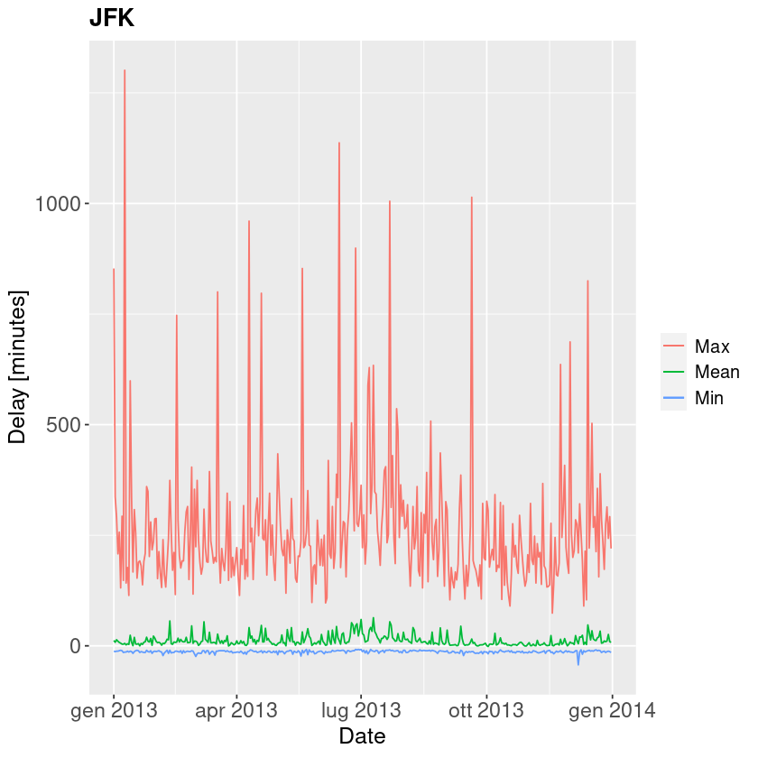

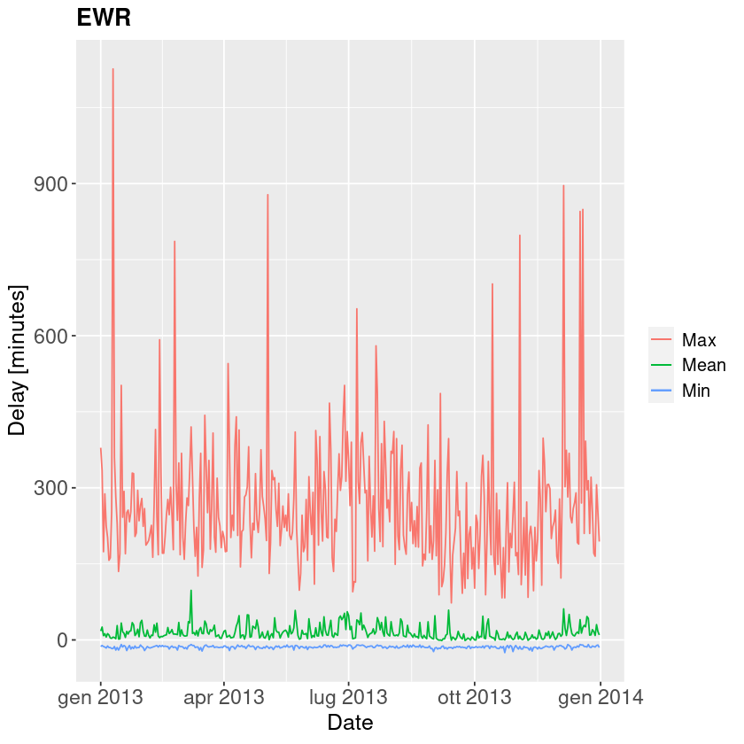

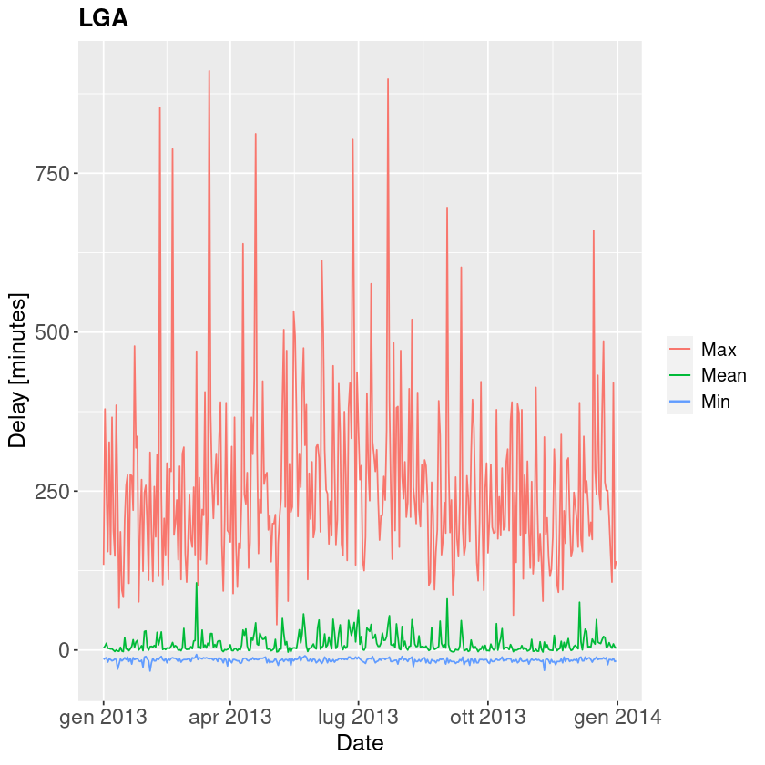

```r
#Make plots for each airport
origins <- c("JFK", "EWR", "LGA")
quantities <- c("Mean", "Max", "Min")
for(airport in origins){
    p <- ggplot()
    line_min <- geom_line(mins[mins$origin==airport,], mapping = aes(x=mins[mins$origin==airport,]$date, y=mins[mins$origin==airport,]$x, color = "Min"))
    line_max <- geom_line(maxs[mins$origin==airport,], mapping = aes(x=maxs[mins$origin==airport,]$date, y=maxs[mins$origin==airport,]$x, color = "Max"))
    line_mean <- geom_line(means[mins$origin==airport,], mapping = aes(x=means[mins$origin==airport,]$date, y=means[mins$origin==airport,]$x, color = "Mean"))
    labels <- labs(x = "Date", y = "Delay [minutes]", colour = NULL)

    p <- p + line_min + line_max + line_mean + themes + ggtitle(airport) + labels
    print(p)
}
```

#### 3) Assuming the distance flew by the plane is, at first approximation, the distance between the two connecting airports (as given in the data frame), compute the average speed of each plane. Produce a plot of the average plane speed as a function of departure day of the year

```r
#Distance is written in miles, air_time is in minutes --> let's convert to km/h
flights <- flights %>% add_column(speed_kmh = flights$distance*1.60934/(flights$air_time/60))
```

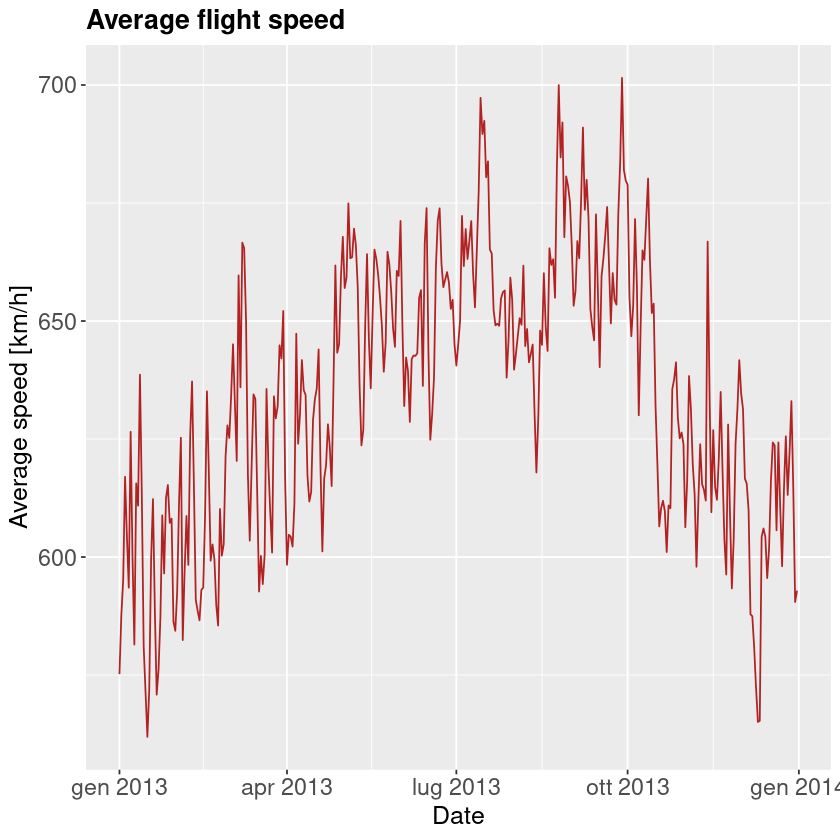

```r
#Plot of average speed as function of departure day
avg_speed <- aggregate(flights$speed_kmh,list(date = flights$date),function(x) return(mean(x,na.rm=TRUE)))
labels <- labs(x = "Date", y = "Average speed [km/h]")

p <- ggplot() + geom_line(aes(x = avg_speed$date, y = avg_speed$x), color = "firebrick") + themes + labels + ggtitle("Average flight speed")
print(p)
```

#### 4) - Find the airline companies offering the largest two numbers of flights per day and per week

##### Per day:

```r
#Count flights per day and per company
airlines_per_day <- count(flights, carrier, date)

#Function to find two carriers with most flights --> returns c(second_to_max, max)
find_two_max<-function(x){
    indices <- order(x$n)
    return(tail(x$carrier[indices],2))
}

#Apply find_two_max function, grouping rows by date
max_per_day <- airlines_per_day %>% group_by(date) %>% do(data.frame(maxCarrier2=find_two_max(.)))

#Tidy up data
max_per_day <- max_per_day %>% add_column(maxCarrier = c(tail(max_per_day$maxCarrier2,length(max_per_day$maxCarrier2)-1), head(max_per_day$maxCarrier2,1))) %>% distinct(.,date, .keep_all=TRUE)

#Add columns with number of flights, for future plotting
max_per_day <- max_per_day %>% add_column(max = aggregate(airlines_per_day$n, list(airlines_per_day$date), max)$x)
max_per_day <- max_per_day %>% add_column(max2 = aggregate(airlines_per_day$n, list(airlines_per_day$date), function(x) max(x[-order(x)[length(x)]]))$x)
max_per_day <- max_per_day %>% relocate(max2, .after = maxCarrier2)
```

```r
#Show first rows as an example
head(max_per_day,15)
```

A grouped_df: 15 × 5

| date <date> | maxCarrier2 <chr> | max2 <int> | maxCarrier <chr> | max <int> |
| --- | --- | --- | --- | --- |
| 2013-01-01 | B6 | 163 | UA | 165 |
| 2013-01-02 | B6 | 162 | UA | 170 |
| 2013-01-03 | UA | 159 | B6 | 162 |
| 2013-01-04 | B6 | 161 | UA | 161 |
| 2013-01-05 | UA | 117 | B6 | 154 |
| 2013-01-06 | UA | 137 | B6 | 156 |
| 2013-01-07 | EV | 149 | UA | 158 |
| 2013-01-08 | EV | 144 | UA | 156 |
| 2013-01-09 | EV | 147 | UA | 156 |
| 2013-01-10 | EV | 151 | UA | 158 |
| 2013-01-11 | B6 | 150 | UA | 158 |
| 2013-01-12 | UA | 112 | B6 | 132 |
| 2013-01-13 | UA | 137 | B6 | 147 |
| 2013-01-14 | EV | 150 | UA | 157 |
| 2013-01-15 | EV | 147 | UA | 155 |

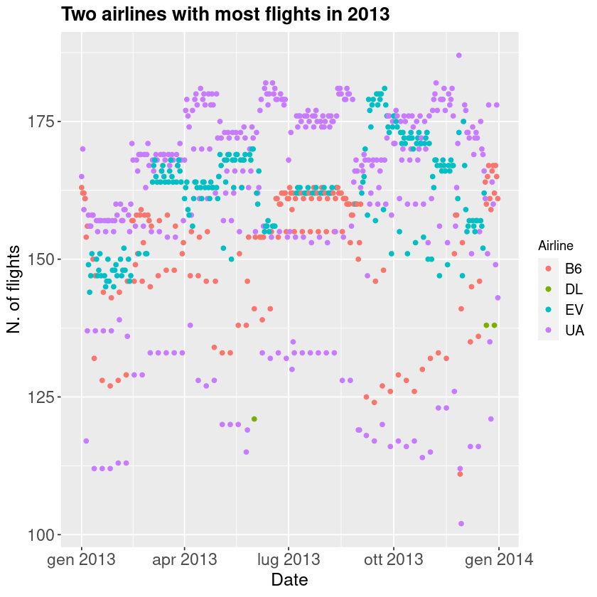

```r
#Scatter plot
p <- ggplot()
scatter_max <- geom_point(max_per_day, mapping = aes(x = date, y = max, color = maxCarrier))
scatter_max2 <- geom_point(max_per_day, mapping = aes(x = date, y = max2, color = maxCarrier2))
p <- p + scatter_max + scatter_max2
labels <- labs(x = "Date", y = "N. of flights", colour = "Airline")
p <- p + ggtitle("Two airlines with most flights in 2013") + labels + themes

print(p)
```

Each day of 2013, the company with the highest number of flights was either Delta Air Lines (DL), JetBlue Airways (B6), ExpressJet Airlines (EV), or United Air Lines (UA).

##### Per week:

```r
#Count flights per week and per company
airlines_per_week <- count(flights%>%add_column(week = week(flights$date)), carrier, week)

#Apply find_two_max function, grouping rows by week
max_per_week <- airlines_per_week %>% group_by(week) %>% do(data.frame(maxCarrier2=find_two_max(.)))

#Tidy up data
max_per_week <- max_per_week %>% add_column(maxCarrier = c(tail(max_per_week$maxCarrier2,length(max_per_week$maxCarrier2)-1), head(max_per_week$maxCarrier2,1))) %>% distinct(.,week, .keep_all=TRUE)

#Add columns with number of flights, for future plotting
max_per_week <- max_per_week %>% add_column(max = aggregate(airlines_per_week$n, list(airlines_per_week$week), max)$x)
max_per_week <- max_per_week %>% add_column(max2 = aggregate(airlines_per_week$n, list(airlines_per_week$week), function(x) max(x[-order(x)[length(x)]]))$x)
max_per_week <- max_per_week %>% relocate(max2, .after = maxCarrier2)
```

```r
head(max_per_week)
```

A grouped_df: 6 × 5

| week <dbl> | maxCarrier2 <chr> | max2 <int> | maxCarrier <chr> | max <int> |
| --- | --- | --- | --- | --- |
| 1 | UA | 1067 | B6 | 1107 |
| 2 | B6 | 993 | UA | 1034 |
| 3 | B6 | 968 | UA | 1032 |
| 4 | B6 | 959 | UA | 1032 |
| 5 | B6 | 965 | UA | 1042 |
| 6 | B6 | 971 | UA | 1039 |

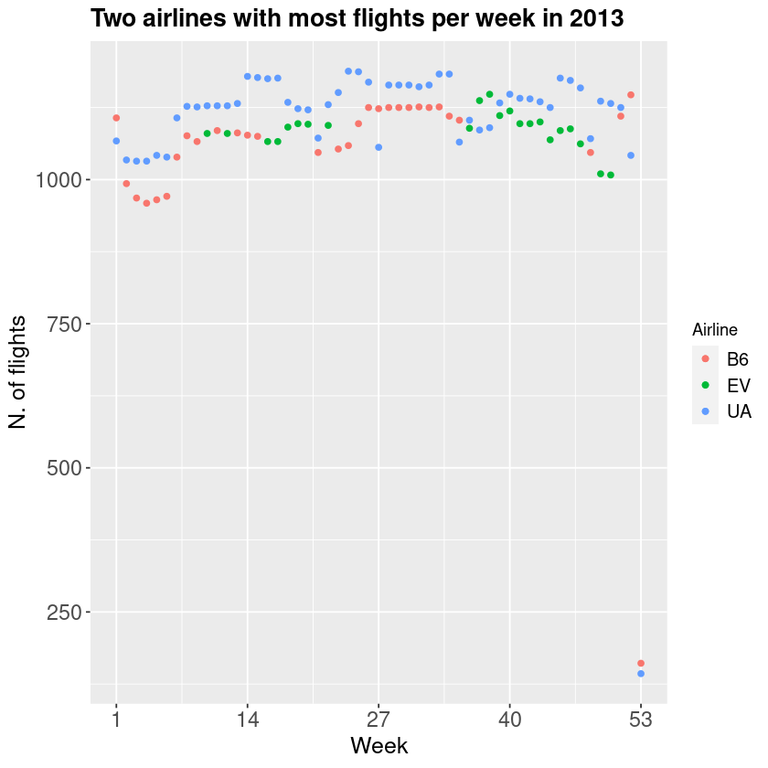

```r
#Scatter plot
p <- ggplot()
scatter_max <- geom_point(max_per_week, mapping = aes(x = week, y = max, color = maxCarrier))
scatter_max2 <- geom_point(max_per_week, mapping = aes(x = week, y = max2, color = maxCarrier2))
p <- p + scatter_max + scatter_max2
labels <- labs(x = "Week", y = "N. of flights", colour = "Airline")
p <- p + ggtitle("Two airlines with most flights per week in 2013") + labels + themes + scale_x_continuous(breaks= x_ticks)

print(p)
```

Each week in 2013, the company that offered the highest number of flights was either JetBlue Airways (B6), ExpressJet Airlines (EV), or United Air Lines (UA).

#### - The airline company offering the smallest number of flights per month

```r
airlines_per_month <- count(flights, carrier, month) #Count flights per day and per company

find_min<-function(x){
    indices <- order(x$n)
    return(head(x$carrier[indices],1))
}

#Apply find_min function, grouping rows by month
min_per_month <- airlines_per_month %>% group_by(month) %>% do(data.frame(carrier=find_min(.)))

#Add a column with the corresponding number of flights, for future plotting
min_per_month <- min_per_month %>% add_column(n = aggregate(airlines_per_month$n, list(airlines_per_month$month), min)$x)
```

```r
min_per_month
```

A grouped_df: 12 × 3

| month <int> | carrier <chr> | n <int> |
| --- | --- | --- |
| 1 | OO | 1 |
| 2 | HA | 28 |
| 3 | YV | 18 |
| 4 | HA | 30 |
| 5 | HA | 31 |
| 6 | OO | 2 |
| 7 | HA | 31 |
| 8 | OO | 4 |
| 9 | OO | 20 |
| 10 | HA | 21 |
| 11 | OO | 5 |
| 12 | HA | 28 |

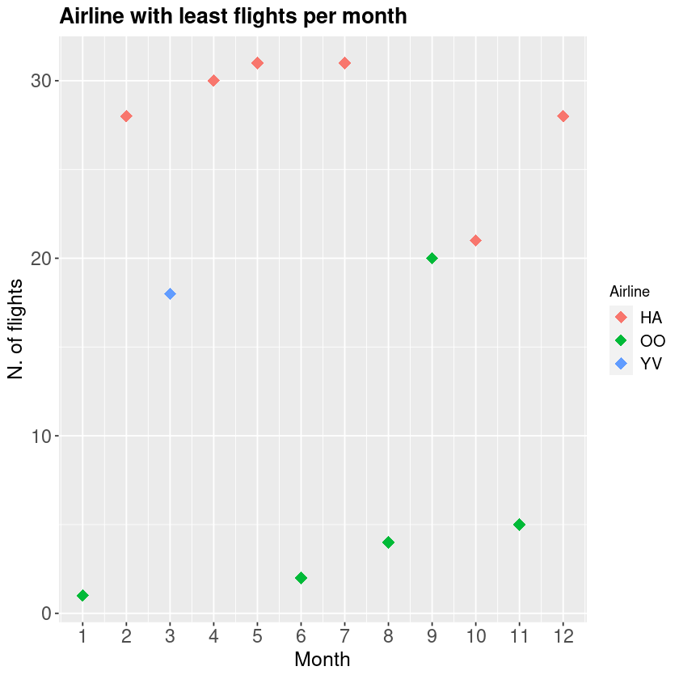

```r
### Scatter plot
p <- ggplot()
scatter_max <- geom_point(min_per_month, mapping = aes(x = month, y = n, color = carrier), size = 4, shape = "diamond")
p <- p + scatter_max
labels <- labs(x = "Month", y = "N. of flights", colour = "Airline")
x_ticks <- seq(1,12, by = 1)


p <- p + ggtitle("Airline with least flights per month") + labels + themes + scale_x_continuous(breaks= x_ticks)

print(p)
```

Each month, the airline with the smallest number of flights is either SkyWest Airlines (OO), Hawaiian Airlines (HA), or Mesa Airlines (YV).

#### - The airline company offering the longest distance flight per month.

```r
find_longest<-function(x){
    indices <- order(x$distance)
    return(tail(x$carrier[indices],1))
}

find_distance <- function(x){
    return(max(x$distance))
}


longest_per_month <- flights %>% group_by(month) %>% do(data.frame(carrier=find_longest(.)))

#Add a column with the corresponding distance, for future plotting
longest_per_month <- longest_per_month %>% add_column(distance = aggregate(flights$distance, list(flights$month), max)$x)
```

```r
longest_per_month
```

A grouped_df: 12 × 3

| month <int> | carrier <chr> | distance <dbl> |
| --- | --- | --- |
| 1 | HA | 4983 |
| 2 | HA | 4983 |
| 3 | HA | 4983 |
| 4 | HA | 4983 |
| 5 | HA | 4983 |
| 6 | HA | 4983 |
| 7 | HA | 4983 |
| 8 | HA | 4983 |
| 9 | HA | 4983 |
| 10 | HA | 4983 |
| 11 | HA | 4983 |
| 12 | HA | 4983 |

```r
flights[flights$carrier == "HA" & flights$distance == 4983, ] %>% select(origin, dest) %>% unique()
```

A tibble: 1 × 2

| origin <chr> | dest <chr> |
| --- | --- |
| JFK | HNL |

Each month, the longest flight is the one from JFK airport to Honolulu airport.